# 09 Prepare : Reading

## Objectives

- Introduction to 2D and 3D computer graphics.
- WebGL and Threejs
- JavaScript

## Computer Graphics Pipeline

> A computer graphics pipeline, rendering pipeline or simply graphics pipeline, is a conceptual model in computer graphics that describes what steps a graphics system needs to perform to render a 3D scene to a 2D screen.[1] Plainly speaking, once a 3D model has been created, for instance in a video game or any other 3D computer animation, the graphics pipeline is the process of turning that 3D model into what the computer displays.[2] Because the steps required for this operation highly depend on the software and hardware used and the desired display characteristics, there is no universal graphics pipeline suitable for all cases. However, graphics APIs such as Direct3D and OpenGL were created to unify similar steps and to control the graphics pipeline of a given hardware accelerator. These APIs primarily abstract the underlying hardware and keep the programmer away from writing code to manipulate the graphics hardware accelerators (AMD/Intel/NVIDIA etc.).

> The model of the graphics pipeline is usually used in real-time rendering. Often, most of the pipeline steps are implemented in hardware, which allows for special optimizations. The term "pipeline" is used in a similar sense to the pipeline in processors: the individual steps of the pipeline run parallel but are blocked until the slowest step has been completed.

[Link to the article above](https://en.wikipedia.org/wiki/Graphics_pipeline)

**OpenGL PipeLine**

The "programmable" steps in the pipeline below is where shaders can be written. Shader code is run directly on the hardware of the GPU and is very fast.

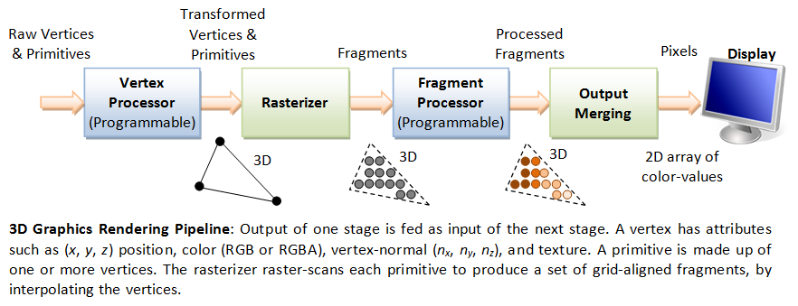

**Coordinate System**

2D coordinate system is the system your learned in high school in geometry class.

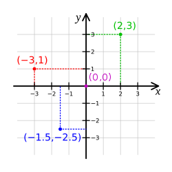

3D coordinate system that is used for computer graphics.

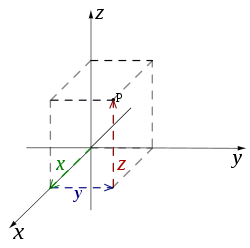

3D coordinate system can be left or right handed. It doesn't matter which one you use, just be consistent. If you place your thumb on Y-axis, middle figure on X-axis, your index figure needs to point towards positive Z-axis.

[figure not shown]

[Link to Coordinate System webpage](https://en.wikipedia.org/wiki/Coordinate_system)

**Everything is a triangle**

Here is a video on how triangle are used in computer graphics.

[Link to video](https://www.youtube.com/watch?v=KdyvizaygyY)

https://en.wikipedia.org/wiki/Polygon_triangulation

## WebGL

[WebGL Webiste](https://get.webgl.org/)

**What Is WebGL?**

WebGL is a cross-platform, royalty-free API used to create 3D graphics in a Web browser. Based on OpenGL ES 2.0, WebGL uses the OpenGL shading language, GLSL, and offers the familiarity of the standard OpenGL API. Because it runs in the HTML5 Canvas element, WebGL has full integration with all Document Object Model (DOM) interfaces.

WebGL is a DOM API, which means that it can be used from any DOM-compatible language: JavaScript, Java, or—if you embed WebKit into an application on a Mac—Objective C.

Major browser vendors Google (Chrome), Opera (Opera), Mozilla (Firefox), and Apple (Safari) are members of the Khronos consortium's WebGL Working Group, along with many other 3D graphics developers.

**Key Advantages**

Because it is based on OpenGL and will be integrated across popular browsers, WebGL offers a number of advantages, among them:

An API that is based on a familiar and widely accepted 3D graphics standard Cross-browser and cross-platform compatibility Tight integration with HTML content, including layered compositing, interaction with other HTML elements, and use of the standard HTML event handling mechanisms Hardware-accelerated 3D graphics for the browser environment A scripting environment that makes it easy to prototype 3D graphics—you don't need to compile and link before you can view and debug the rendered graphics

**Key Point of WebGL**

It is a **low level** graphics API. Meaning that it draws lines, ploygons, colors, etc. very fast, however, you as a programmer must do a lot when writting applications.

## ThreeJS

- [ThreeJS website](https://threejs.org/)
- Please read this article on the [ThreeJS fundamentals](https://threejsfundamentals.org/threejs/lessons/threejs-fundamentals.html)

**What is ThreeJS**

Three.js is a cross-browser JavaScript library and application programming interface (API) used to create and display animated 3D computer graphics in a web browser using WebGL. It runs on WebGL and has graphical objects that you can use to build applications.

We will be learning ThreeJS for the rest of the semester.

### Example Hello Box ThreeJS Program

In order to run a ThreeJS program, you need to include the ThreeJS library. This can be a include to one on the Internet or to a local JS file. We will be using a local file. Notice in the example program below that we are using `three.min.js` for the library . Look in the `resources` folder in GitHub for this library file.

```
<html>
    <head>
        <title>My first Three.js app</title>
        <style>
            body { margin: 0; }
            canvas { width: 100%; height: 100% }
        </style>
</head>
<body>

    <div id="ThreeJS" style="position: absolute; left:0px; top:0px"></div>
    <script src="three.min.js"></script>

    <script>

        var scene, camera, renderer;
        var geometry, material, mesh;

        init();
        animate();

        function init() {

            // Create the main scene for the 3D drawing
            scene = new THREE.Scene();

            // Every scene needs a camera
            camera = new THREE.PerspectiveCamera(75, window.innerWidth / window.innerHeight, 1, 10000);
            camera.position.x = 30;
            camera.position.y = 30;
            camera.position.z = 80;

            camera.lookAt(new THREE.Vector3(0,0,0));

            // Add objects into the scene
            geometry = new THREE.BoxGeometry(20, 20, 20);
            // geometry = new THREE.CylinderGeometry(20, 20, 20, 20);
            material = new THREE.MeshBasicMaterial( { color: 0xff0000, wireframe: true} );

            // a mesh needs the geometry (aka lines and points) and material (aka surface)
            mesh = new THREE.Mesh( geometry, material );
            scene.add( mesh );

            object = new THREE.AxisHelper( 50 );
            object.position.set( 0, 0, 0 );
            scene.add( object );

            // the renderer renders the scene using the objects, lights and camera
            renderer = new THREE.WebGLRenderer();
            renderer.setSize( window.innerWidth, window.innerHeight );

            // Attach the threeJS renderer to the HTML page
            document.body.appendChild( renderer.domElement );

        }

        // This is the game/animation loop
        // This is called ~60 times a second
        function animate() {

            requestAnimationFrame( animate );

            // Move anything you what
            mesh.rotation.x += 0.01;
            mesh.rotation.y += 0.01;
            mesh.rotation.z += 0.01;

            renderer.render( scene, camera );
        }

</script>

</body>
</html>
```

## Babylon.js

[Babylon.js Website](https://www.babylonjs.com/)

Babylon.js is a real time 3D engine using a JavaScript library for displaying 3D graphics in a web browser via HTML5. The source code is available on GitHub and distributed under the Apache License 2.0.

We will not be going over babylon in this course.

## JavaScript

We will be learning JavaScript in order to use ThreeJS. It is not hard to pick up and we don't need to be javascript experts.